# Week 3: Optimization under uncertainty

Robust optimization and chance constraints

Gareth Green

# Load packages

```r
# Load packages
library(lpSolveAPI)
`%>%` <- magrittr::`%>%`
library(knitr)
library(kableExtra)
```

# Homework #1, problem #4: Farming maximization

- Maximize:

  profit = 5G + 25V
- Subject to:

  Materials 5G + 40V <= 1245  
  Water 4G + 8V <= 300

```r
# Define parameters of the lp
h1p4 <- make.lp(0, 2)
```

```r
# Set up model
obj_fn <- c(5, 25)
set.objfn(h1p4, obj_fn)
add.constraint(h1p4, c(5, 40), "<=", 1245)
add.constraint(h1p4, c(4, 8), "<=", 300)

# Add row and column names
dimnames(h1p4) <- list(c("Input Mix", "Water"),
                     c("Grains", "Veggies"))

# See the model we have set up
h1p4
```

```
## Model name:
##             Grains  Veggies
## Maximize         5       25
## Input Mix        5       40  <=  1245
## Water            4        8  <=   300
## Kind           Std      Std
## Type          Real     Real
## Upper          Inf      Inf
## Lower            0        0
```

# Recall the graphical representation

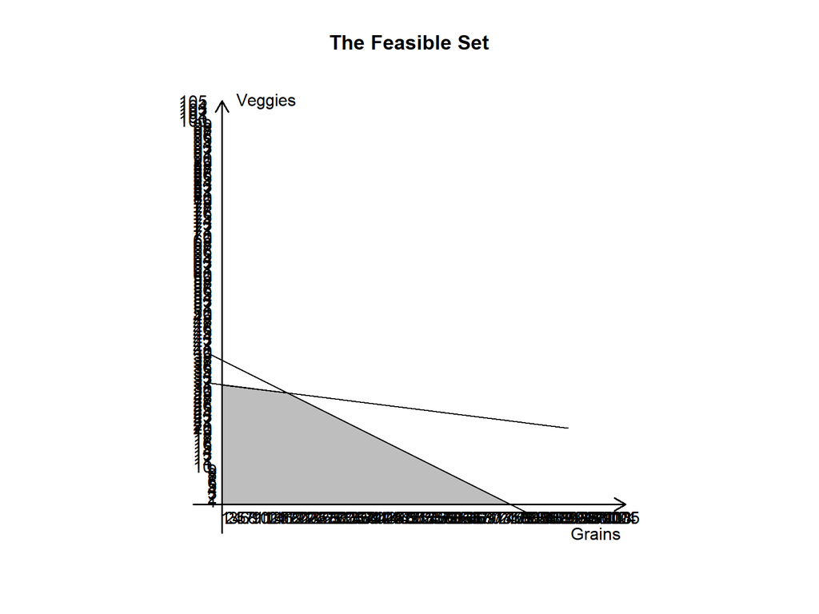

# Objective value and sensitivity analysis table

|  | Input Mix | Water | Grains | Veggies |
| --- | --- | --- | --- | --- |
| Solution | 1,245.0 | 300.00 | 17.00 | 29 |
| duals/coef | 0.5 | 0.62 | 5.00 | 25 |
| Sens From | 375.0 | 249.00 | 3.12 | 10 |
| Sens Till | 1,500.0 | 996.00 | 12.50 | 40 |

Objective Value = 810

**What changes in the right hand side constraints (*b*’s) would change the solution**

- Duals indicate both the input mix and water constraints are binding
  - Increasing water will increase profit by $0.62 per unit from 249 to 996 units
  - Increasing input mix will increase profit by $0.50 per unit from 375 to 1500 units
  - Increasing either resource will increase profits
    - But not sure how crops (variables) will change

**What changes in the objective function parameters (*c*’s) would change the solution**

**What changes in the constraint parameters (*a*’s) would change the solution**

- This type of sensitivity analysis is not given by the output
  - Ratio of $c$’s is 25/5 = 5
  - Ratio of $a_i$ is 40/5 = 8, so $a_{Vi}$ decrease or $a_{Gi}$ increase so ratio < 5
  - Ratio of $a_w$ is 8/4 = 2, so $a_{VW}$ increase or $a_{GW}$ decrease so ratio > 5

**Let’s try it to see**

# Robust Optimization-INDEPENDENT parameters

**Drought parameters**

- lower bound of c’s: $c_G = 3$ and $c_V = 20$
- lower bound of water: $b_W = 200$
- upper bound of a’s: $a_{GW} = 5$ and $a_{VW} = 10$
- maximize:

  profit = 3G + 20V
- subject to:

  Materials 5G + 40V <= 1245  
  Water 5G + 10V <= 200

**Write down how you think the solution will change?**

- Objective value +/-
- Duals +/-
- Variables (acreage) +/-

```r
# Define parameters of the lp
h1p4_ro_i <- make.lp(0, 2)
```

# Objective value and sensitivity analysis table

|  | Input Mix | Water | Grains | Veggies |
| --- | --- | --- | --- | --- |
| Solution | 800 | 200 | 0 | 20 |
| duals/coef | 0 | 2 | 3 | 20 |
| Sens From | -inf | 0 | -inf | 6 |
| Sens Till | inf | 311.25 | 10 | inf |

Objective Value = 400

**How do results compare to your guess?**

- Objective function decrease
- Only water binding and the water dual increased
- Stop grains, reduce veggie

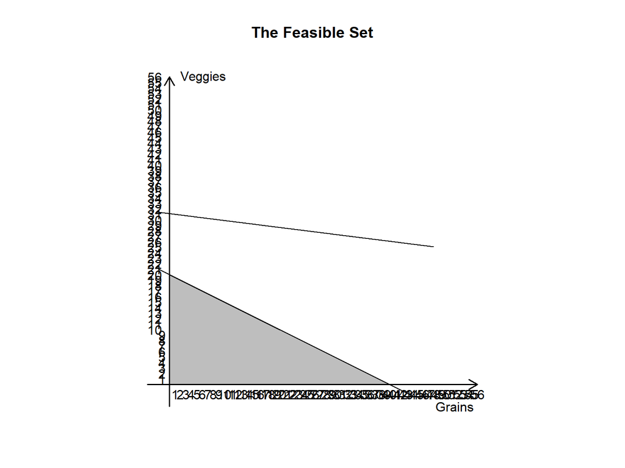

# Did robust optimization rules make sense?

Note: we applied the Robust Optimization rule WITHOUT considering the application

- **Does it make sense?**
  - How would water use change during drought?
    - Might be hotter so need more water, so yes that make sense
  - How would c’s and profit change?
    - Grains price stay same due to world market, so not good assumption
    - Veggie profit +/-?
      - If mkt supply down, price increase, profit increase
      - If water more due to heat could be more expensive, profit decrease
        - hard to say how profit per acre react
        - leave at usual price
- So water use realistic, but profit parameters need to be studied

# Robust Optimization-DEPENDENT parameters

**Drought parameters**

- Assume grains profit the same but veggies profit increase due to reduced supply
  - Putting in fixed values derived from functional relationship
- fixed functional value of c’s: $c_G = 5$ and $c_V = 25$
- lower bound of water: $b_W = 200$
- upper bound of a’s: $a_{GW} = 5$ and $a_{VW} = 10$
- refine c’s: $c_G = 5$ and $c_V = 25$
  - Base value of c for grain since world market
  - Higher profit for veggie since lower production
    - However, this is not conservative approach
- lower bound of water: $b_W = 200$
- upper bound of a’s: $a_{GW} = 5$ and $a_{VW} = 10$
  - since use more water if hotter in drought

**Why is this robust optimization with dependent parameters?**

- Have changed parameters based on case rather than just follow rules
- Have simplified to use linear programming
  - Not have a’s or c’s as function of water or temperature
- maximize:

  profit = 5G + 25V
- subject to:

  Materials 5G + 40V <= 1245  
  Water 5G + 10V <= 200

**Write down how you think the solution will change?**

- Objective value +/-
- Duals +/-
- Variables (acreage) +/-

```r
# Define parameters of the lp
h1p4_ro_d <- make.lp(0, 2)
```

# Objective value and sensitivity analysis table

[output not shown]

Objective Value = 500

**How do results compare to your guess?**

- Objective function decrease, but not by as much as before (was $400)
- Only water binding and the water dual increased
- Stop grains, reduce veggie

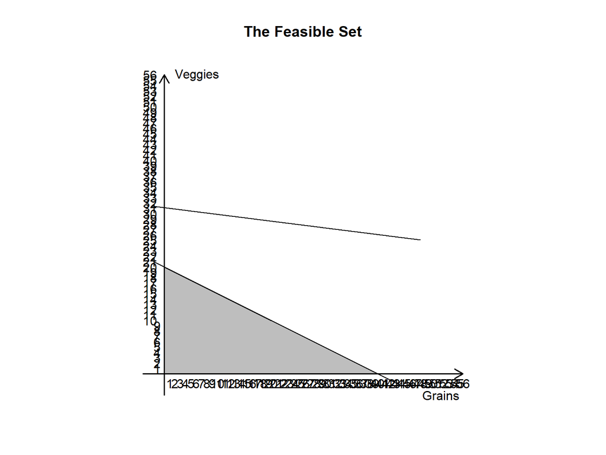

# Chance Constraint

**Drought parameters**

- use refined c’s: $c_{GW} = 5$ and $c_{VW} = 25$
  - Base profit of c for grain and for veggie (since not know how change)
- upper bound of a’s: $a_{GW} = 5$, $a_{VW} = 10$
  - since use more water

Suppose distribution of water is $\mu = 300$ and $\sigma = 50$

- Lower bound of water: $b_{water}\le\mu-K_{\alpha}*\sigma=300-K_{\alpha}*50$
- Use 90% confidence so $\alpha = 0.1$
- But is a two-tail so only get 0.05 in lower tail
- maximize:

  profit = 5G + 25V
- subject to:

  Materials 5G + 40V <= 1245  
  Water 5G + 10V <= 300 - $K_{\alpha}$ * 50

**Write down how you think the solution will change?**

- Objective value +/-
- Duals +/-
- Variables (acreage) +/-

```r
# Define parameters of the lp
h1p4_cc <- make.lp(0, 2)
```

# Objective value and sensitivity analysis table

|  | Input Mix | Water | Grains | Veggies |
| --- | --- | --- | --- | --- |
| Solution | 871.03 | 217.76 | 0 | 21.78 |
| duals/coef | 0 | 2.5 | 5 | 25 |
| Sens From | -inf | 0 | -inf | 10 |
| Sens Till | inf | 311.25 | 12.5 | inf |

Objective Value = 544.393296631066

**How do results compare to your guess?**

- Objective function decrease
  - But not by as much since since lower bound 218 > 200
- Only water binding and the water dual increased
- Stop grains, reduce veggie

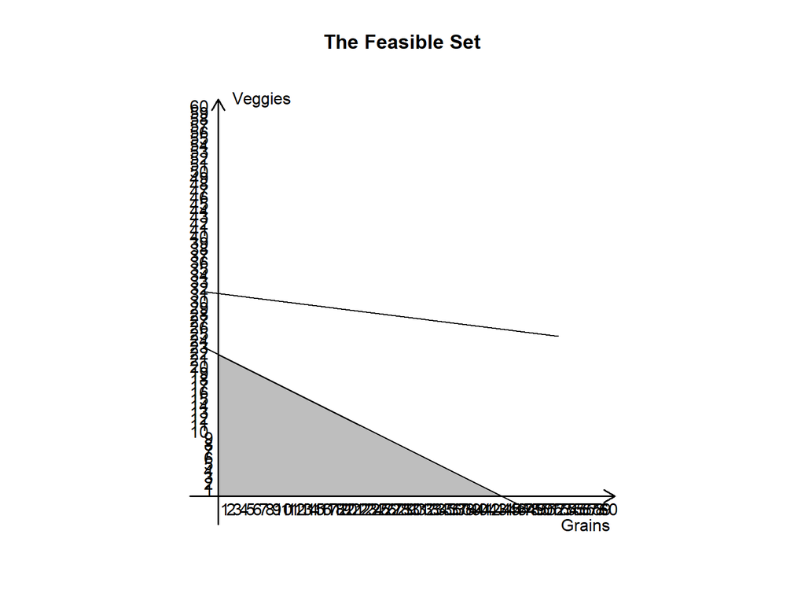